# Acquiring and wrangling with data

In previous sessions, we've talked about the underlying data structures in the `Pandas` library. We've seen how to manipulate `DataFrame` and `Series` objects in order to answer questions regarding the data. Last week, we also saw how to use `matplotlib` to visualize our analysis.

This week we will be diving into an important topic in `Pandas`: aggregating and performing operations on specified groups of data without modifying the underlying structure. According to Wes McKinney,

> Categorizing a data set and applying a function to each group, whether an aggregation or transformation, is often a critical component of a data analysis workflow. After loading, merging, and preparing a data set, a familiar task is to compute group statistics or possibly *pivot tables* for reporting or visualization purposes. `Pandas` provides a flexible and high-performance `groupby` facility, enabling you to slice and dice, and summarize data sets in a natural way.

```python
from __future__ import division
from numpy.random import randn
import numpy as np
import os
import matplotlib.pyplot as plt
np.random.seed(12345)
plt.rc('figure', figsize=(10, 6))
from pandas import Series, DataFrame
import pandas as pd
np.set_printoptions(precision=4)
```

# Data Aggregation and Group Operations

```python
pd.options.display.notebook_repr_html = False
%matplotlib inline
```

## GroupBy mechanics

`Pandas` was designed with a considerable deference to the progress made in data aggregation techniques by developers for the `R` programming language. The main mechanism is the *split-apply-combine* paradigm:

1. Data is *split* into groups based on one or more provided *keys*,
2. A function is *applied* to each group,
3. The results of all the function applications are *combined* into a result object.

As we will see, grouping keys are very flexible in nature. Some possible types of keys are

- A list or array of values sharing the length of the grouped column
- A value indicating a column name
- A dict or `Series` giving a correspondence between the values on the axis being grouped and the group names
- A function to be invoked on the axis index or the individual labels in the index

```python
df = DataFrame({'key1' : ['a', 'a', 'b', 'b', 'a'],
                'key2' : ['one', 'two', 'one', 'two', 'one'],
                'data1' : np.random.randn(5),
                'data2' : np.random.randn(5)})
df
```

```
      data1     data2 key1 key2
0 -0.204708  1.393406    a  one
1  0.478943  0.092908    a  two
2 -0.519439  0.281746    b  one
3 -0.555730  0.769023    b  two
4  1.965781  1.246435    a  one
```

We can compute the mean of the column corresponding to "data1" by using the group labels from "key1". This can be done in a number of ways, but here is a straightforward example:

```python
grouped = df['data1'].groupby(df['key1'])
grouped
```

```
<pandas.core.groupby.SeriesGroupBy object at 0x7f37d9157050>
```

Notice that `grouped` is its own `Pandas` object, just like a `Series` or `DataFrame`. Now we can compute simple statistics just like we would with other objects.

```python
grouped.mean()
```

```
key1
a       0.746672
b      -0.537585
Name: data1, dtype: float64
```

We can also pass an array of keys:

```python
means = df['data1'].groupby([df['key1'], df['key2']]).mean()
means
```

```
key1  key2
a     one     0.880536
      two     0.478943
b     one    -0.519439
      two    -0.555730
Name: data1, dtype: float64
```

This forms a grouping using a heierarchical index, as we have seen earlier. To flatten the hierarchical index, as we have seen, we can call `unstack()`.

```python
means.unstack()
```

```
key2       one       two
key1
a     0.880536  0.478943
b    -0.519439 -0.555730
```

In these examples, the keys refer to `Series`, though they could really be anything so long as the lengths match up. For example, consider the following key arrays.

```python
states = np.array(['Ohio', 'California', 'California', 'Ohio', 'Ohio'])
years = np.array([2005, 2005, 2006, 2005, 2006])
df['data1'].groupby([states, years]).mean()
```

```
California  2005    0.478943
            2006   -0.519439
Ohio        2005   -0.380219
            2006    1.965781
Name: data1, dtype: float64
```

If you're just interested in the column names, you can simply pass the identifying string, or list of strings, as in the following examples:

```python
df.groupby('key1').mean()
```

```
         data1     data2
key1
a     0.746672  0.910916
b    -0.537585  0.525384
```

```python
df.groupby(['key1', 'key2']).mean()
```

```
              data1     data2
key1 key2
a    one   0.880536  1.319920
     two   0.478943  0.092908
b    one  -0.519439  0.281746
     two  -0.555730  0.769023
```

```python
df.groupby(['key1', 'key2']).size()
```

```
key1  key2
a     one     2
      two     1
b     one     1
      two     1
dtype: int64
```

### Iterating over groups

`groupby()` supports iteration. Specifically, `groupby()` produces tuples containing the group name along the relevant data. For example:

```python
for name, group in df.groupby('key1'):
    print(name)
    print(group)
```

```
a
      data1     data2 key1 key2
0 -0.204708  1.393406    a  one
1  0.478943  0.092908    a  two
4  1.965781  1.246435    a  one
b
      data1     data2 key1 key2
2 -0.519439  0.281746    b  one
3 -0.555730  0.769023    b  two
```

If multiple keys are being passed, you can overload the name by making a $n$-tuple of keys. For example:

```python
for (k1, k2), group in df.groupby(['key1', 'key2']):
    print((k1, k2))
    print(group)
```

```
('a', 'one')
      data1     data2 key1 key2
0 -0.204708  1.393406    a  one
4  1.965781  1.246435    a  one
('a', 'two')
      data1     data2 key1 key2
1  0.478943  0.092908    a  two
('b', 'one')
      data1     data2 key1 key2
2 -0.519439  0.281746    b  one
('b', 'two')
     data1     data2 key1 key2
3 -0.55573  0.769023    b  two
```

This process is in general quite flexible. For example, suppose you want to store the relevant `DataFrame` groups as a native-`Python` dict. In this case, we can just wrap the `groupby()` call with a list and a dict, which will thus be stored into the dict.

```python
pieces = dict(list(df.groupby('key1')))
pieces['b']
```

```
      data1     data2 key1 key2
2 -0.519439  0.281746    b  one
3 -0.555730  0.769023    b  two
```

By default, `groupby` groups on `axis=0`, which corresponds to treating columns of data. Of course, you can specify which axis you desire.

```python
df.dtypes
```

```
data1    float64
data2    float64
key1      object
key2      object
dtype: object
```

```python
grouped = df.groupby(df.dtypes, axis=1)
dict(list(grouped))
```

```
{dtype('float64'):       data1     data2
 0 -0.204708  1.393406
 1  0.478943  0.092908
 2 -0.519439  0.281746
 3 -0.555730  0.769023
 4  1.965781  1.246435, dtype('O'):   key1 key2
 0    a  one
 1    a  two
 2    b  one
 3    b  two
 4    a  one}
```

### Selecting a column or subset of columns

Indexing a `GroupBy` object created from a `DataFrame` with a column name or array of column names has the efect of *selecting those columns* for aggregation. This means that:

```
df.groupby('key1')['data1']
df.groupby('key1')[['data2']]
```

is effectively identical to

```
df['data1'].groupby(df['key1'])
df[['data2']].groupby(df['key1'])
```

Why is this useful? If you're working with a large dataset for which aggregating the entire `DataFrame` is out of the question, you can speed up the process by specifying the particular columns you are interested in.

Here's an example: we can group a `DataFrame` according to a set of keys, specify a particular column (in this case, `data2`), and take the resulting mean.

```python
df.groupby(['key1', 'key2'])[['data2']].mean()
```

```
              data2
key1 key2
a    one   1.319920
     two   0.092908
b    one   0.281746
     two   0.769023
```

The object returned here is a grouped `DataFrame` if a list or array is passed and a grouped `Series` if just a column name is passed.

```python
s_grouped = df.groupby(['key1', 'key2'])['data2']
s_grouped
```

```
<pandas.core.groupby.SeriesGroupBy object at 0x7f37d9119350>
```

```python
s_grouped.mean()
```

```
key1  key2
a     one     1.319920
      two     0.092908
b     one     0.281746
      two     0.769023
Name: data2, dtype: float64
```

### Grouping with dicts and Series

Grouping information may exist in a form other than an array. Let's consider another example `DataFrame`.

```python
people = DataFrame(np.random.randn(5, 5),
                   columns=['a', 'b', 'c', 'd', 'e'],
                   index=['Joe', 'Steve', 'Wes', 'Jim', 'Travis'])
people.ix[2:3, ['b', 'c']] = np.nan # Add a few NA values
people
```

```
               a         b         c         d         e
Joe     1.007189 -1.296221  0.274992  0.228913  1.352917
Steve   0.886429 -2.001637 -0.371843  1.669025 -0.438570
Wes    -0.539741       NaN       NaN -1.021228 -0.577087
Jim     0.124121  0.302614  0.523772  0.000940  1.343810
Travis -0.713544 -0.831154 -2.370232 -1.860761 -0.860757
```

Suppose we have a group correspondence for the columns and want to sum together the columns by group.

```python
mapping = {'a': 'red', 'b': 'red', 'c': 'blue',
           'd': 'blue', 'e': 'red', 'f' : 'orange'}
```

The `groupby` method can use the dict natively, allowing you to form `GroupBy` objects on the fly.

```python
by_column = people.groupby(mapping, axis=1)
by_column.sum()
```

```
            blue       red
Joe     0.503905  1.063885
Steve   1.297183 -1.553778
Wes    -1.021228 -1.116829
Jim     0.524712  1.770545
Travis -4.230992 -2.405455
```

The same holds for `Series` objects, which are structurally similar to dicts.

```python
map_series = Series(mapping)
map_series
```

```
a       red
b       red
c      blue
d      blue
e       red
f    orange
dtype: object
```

```python
people.groupby(map_series, axis=1).count()
```

```
        blue  red
Joe        2    3
Steve      2    3
Wes        1    2
Jim        2    3
Travis     2    3
```

### Grouping with functions

In `Python`, functions are simply another data type. You can actually use `groupby` to isolate members of your data set according to a rule, defined by a function. For example:

```python
people.groupby(len).sum()
```

```
          a         b         c         d         e
3  0.591569 -0.993608  0.798764 -0.791374  2.119639
5  0.886429 -2.001637 -0.371843  1.669025 -0.438570
6 -0.713544 -0.831154 -2.370232 -1.860761 -0.860757
```

You can mix and match functions with other data types that we have seen above.

```python
key_list = ['one', 'one', 'one', 'two', 'two']
people.groupby([len, key_list]).min()
```

```
              a         b         c         d         e
3 one -0.539741 -1.296221  0.274992 -1.021228 -0.577087
  two  0.124121  0.302614  0.523772  0.000940  1.343810
5 one  0.886429 -2.001637 -0.371843  1.669025 -0.438570
6 two -0.713544 -0.831154 -2.370232 -1.860761 -0.860757
```

### Grouping by index levels

Finally, you can use heierarchical indexing to perform `groupby` operations. To do this, pass the level number or name using the `level` keyword.

```python
columns = pd.MultiIndex.from_arrays([['US', 'US', 'US', 'JP', 'JP'],
                                    [1, 3, 5, 1, 3]],
                                    names=['cty', 'tenor'])
hier_df = DataFrame(np.random.randn(4, 5), columns=columns)
hier_df
```

```
cty          US                            JP
tenor         1         3         5         1         3
0      0.560145 -1.265934  0.119827 -1.063512  0.332883
1     -2.359419 -0.199543 -1.541996 -0.970736 -1.307030
2      0.286350  0.377984 -0.753887  0.331286  1.349742
3      0.069877  0.246674 -0.011862  1.004812  1.327195
```

```python
hier_df.groupby(level='cty', axis=1).count()
```

```
cty  JP  US
0     2   3
1     2   3
2     2   3
3     2   3
```

## Data aggregation

Wes McKinney defines *data aggregation* as any transformation that takes a dataset or other array and produces scalar values. For example, the simple statistical functions such as

- mean
- max
- min
- sum

are examples of operations taking arrays to numbers. Many of the aggregations that we have seen so far have been optimized for performance, but `Pandas` gives you the functionality to implement customized aggregators.

```python
df
```

```
      data1     data2 key1 key2
0 -0.204708  1.393406    a  one
1  0.478943  0.092908    a  two
2 -0.519439  0.281746    b  one
3 -0.555730  0.769023    b  two
4  1.965781  1.246435    a  one
```

For example, we can use `quantile(x)` (not explicitly implemented for `GroupBy`), which determines the value of $x$th percentile given a `Series` of data.

```python
grouped = df.groupby('key1')
grouped['data1'].quantile(0.9)
```

```
key1
a       1.668413
b      -0.523068
Name: data1, dtype: float64
```

More to the point, you can define your own functions and do `groupby` operations with them. For example, if you are interested in the range of your data sets, you can use:

```python
def peak_to_peak(arr):
    return arr.max() - arr.min()
grouped.agg(peak_to_peak)
```

```
         data1     data2
key1
a     2.170488  1.300498
b     0.036292  0.487276
```

Even method that aren't really aggregations, such as `describe`, still perform useful operations on `GroupBy` objects.

```python
grouped.describe()
```

```
               data1     data2
key1
a    count  3.000000  3.000000
     mean   0.746672  0.910916
     std    1.109736  0.712217
     min   -0.204708  0.092908
     25%    0.137118  0.669671
     50%    0.478943  1.246435
     75%    1.222362  1.319920
     max    1.965781  1.393406
b    count  2.000000  2.000000
     mean  -0.537585  0.525384
     std    0.025662  0.344556
     min   -0.555730  0.281746
     25%   -0.546657  0.403565
     50%   -0.537585  0.525384
     75%   -0.528512  0.647203
     max   -0.519439  0.769023
```

We will continue with the `tips` dataset from previous weeks to show off some of the more advanced features of aggregation. The data set can be found on the course webpage, or [here](http://www.math.grinnell.edu/~kraemerd17/courses/python/course-material/tips.csv), if you're lazy (like us).

```python
tips = pd.read_csv('tips.csv')
# Add tip percentage of total bill
tips['tip_pct'] = tips['tip'] / tips['total_bill']
tips[:6]
```

```
   total_bill   tip     sex smoker  day    time  size   tip_pct
0       16.99  1.01  Female     No  Sun  Dinner     2  0.059447
1       10.34  1.66    Male     No  Sun  Dinner     3  0.160542
2       21.01  3.50    Male     No  Sun  Dinner     3  0.166587
3       23.68  3.31    Male     No  Sun  Dinner     2  0.139780
4       24.59  3.61  Female     No  Sun  Dinner     4  0.146808
5       25.29  4.71    Male     No  Sun  Dinner     4  0.186240
```

### Column-wise and multiple function application

As we've seen, aggregating a `Series` or all of the columns of a `DataFrame` is a matter of using `aggregate` with the desired function or calling a method like `mean` or `std`. However, you may want to aggregate using a different function depending on the column or multiple functions at once. Fotunately, this is straightforward to do, which we will illustrate through a number of examples. First, let's group the tips by `sex` and `smoker`.

```python
grouped = tips.groupby(['sex', 'smoker'])
```

Descriptive statistics, such as `mean`, can be passed to the aggregator as a string.

```python
grouped_pct = grouped['tip_pct']
grouped_pct.agg('mean')
```

```
sex     smoker
Female  No        0.156921
        Yes       0.182150
Male    No        0.160669
        Yes       0.152771
Name: tip_pct, dtype: float64
```

You can also pass a list of functions to do aggregation. If the function is built-in, it passes as a string. Otherwise, one can simply pass the function on its own.

```python
grouped_pct.agg(['mean', 'std', peak_to_peak])
```

```
                   mean       std  peak_to_peak
sex    smoker
Female No      0.156921  0.036421      0.195876
       Yes     0.182150  0.071595      0.360233
Male   No      0.160669  0.041849      0.220186
       Yes     0.152771  0.090588      0.674707
```

To label the columns assigned by `agg`, pass a tuple in for each function, with the first element corresponding to the label of the column.

```python
grouped_pct.agg([('foo', 'mean'), ('bar', np.std)])
```

```
                    foo       bar
sex    smoker
Female No      0.156921  0.036421
       Yes     0.182150  0.071595
Male   No      0.160669  0.041849
       Yes     0.152771  0.090588
```

With a `DataFame` you have more options as you can specify as list of functions to apply to all of the columns or different functions per column.

```python
functions = ['count', 'mean', 'max']
result = grouped['tip_pct', 'total_bill'].agg(functions)
result
```

```
              tip_pct                     total_bill
                count      mean       max      count       mean    max
sex    smoker
Female No          54  0.156921  0.252672         54  18.105185  35.83
       Yes         33  0.182150  0.416667         33  17.977879  44.30
Male   No          97  0.160669  0.291990         97  19.791237  48.33
       Yes         60  0.152771  0.710345         60  22.284500  50.81
```

Here we are using what effectively amounts to a hierarchical index, which we can then slice by choosing columns and subcolumns.

```python
result['tip_pct']
```

```
               count      mean       max
sex    smoker
Female No         54  0.156921  0.252672
       Yes        33  0.182150  0.416667
Male   No         97  0.160669  0.291990
       Yes        60  0.152771  0.710345
```

As above, a list of tuples with custom names can be passed:

```python
ftuples = [('Durchschnitt', 'mean'), ('Abweichung', np.var)]
grouped['tip_pct', 'total_bill'].agg(ftuples)
```

```
                   tip_pct              total_bill
              Durchschnitt Abweichung Durchschnitt Abweichung
sex    smoker
Female No         0.156921   0.001327    18.105185  53.092422
       Yes        0.182150   0.005126    17.977879  84.451517
Male   No         0.160669   0.001751    19.791237  76.152961
       Yes        0.152771   0.008206    22.284500  98.244673
```

You can also specify the particular column of a `DataFrame` that you want to do aggregation on by passing a dict of information. For example,

```python
grouped.agg({'tip' : np.max, 'size' : 'sum'})
```

```
                tip  size
sex    smoker
Female No       5.2   140
       Yes      6.5    74
Male   No       9.0   263
       Yes     10.0   150
```

You can overload a particular column's aggregator functions by making the dict key corresponding to the column reference a list rather than just one function.

```python
grouped.agg({'tip_pct' : ['min', 'max', 'mean', 'std'],
             'size' : 'sum'})
```

```
                tip_pct                               size
                    min       max      mean       std  sum
sex    smoker
Female No      0.056797  0.252672  0.156921  0.036421  140
       Yes     0.056433  0.416667  0.182150  0.071595   74
Male   No      0.071804  0.291990  0.160669  0.041849  263
       Yes     0.035638  0.710345  0.152771  0.090588  150
```

### Returning aggregated data in "unindexed" form

Of course, you can unindex a hierarchical indexed `GroupBy` object by Specifying the `as_index` optional paramter.

```python
tips.groupby(['sex', 'smoker'], as_index=False).mean()
```

```
      sex smoker  total_bill       tip      size   tip_pct
0  Female     No   18.105185  2.773519  2.592593  0.156921
1  Female    Yes   17.977879  2.931515  2.242424  0.182150
2    Male     No   19.791237  3.113402  2.711340  0.160669
3    Male    Yes   22.284500  3.051167  2.500000  0.152771
```

## Group-wise operations and transformations

Aggregation is but one kind of group operation. It is a special case of more general data transformations, taking one-dimensional arrays and reducing them to scalars. Here we will generalize this notion by showing you how to use `apply` and `transform` methods on `DataFrame` objects. Let's revisit our old `DataFrame` of random data.

```python
df
```

```
      data1     data2 key1 key2
0 -0.204708  1.393406    a  one
1  0.478943  0.092908    a  two
2 -0.519439  0.281746    b  one
3 -0.555730  0.769023    b  two
4  1.965781  1.246435    a  one
```

Suppose we want to add a column containing group means for each index. One way to do this is to aggregate, then merge:

```python
k1_means = df.groupby('key1').mean().add_prefix('mean_')
k1_means
```

```
      mean_data1  mean_data2
key1
a       0.746672    0.910916
b      -0.537585    0.525384
```

```python
pd.merge(df, k1_means, left_on='key1', right_index=True)
```

```
      data1     data2 key1 key2  mean_data1  mean_data2
0 -0.204708  1.393406    a  one    0.746672    0.910916
1  0.478943  0.092908    a  two    0.746672    0.910916
4  1.965781  1.246435    a  one    0.746672    0.910916
2 -0.519439  0.281746    b  one   -0.537585    0.525384
3 -0.555730  0.769023    b  two   -0.537585    0.525384
```

This works but is somewhat inflexible. You can think of the operation as transforming the two data columns using the `np.mean` function. Returning to the `people DataFrame` from before, we can use the `transform` method on `GroupBy`.

```python
key = ['one', 'two', 'one', 'two', 'one']
people.groupby(key).mean()
```

```
            a         b         c         d         e
one -0.082032 -1.063687 -1.047620 -0.884358 -0.028309
two  0.505275 -0.849512  0.075965  0.834983  0.452620
```

```python
people.groupby(key).transform(np.mean)
```

```
               a         b         c         d         e
Joe    -0.082032 -1.063687 -1.047620 -0.884358 -0.028309
Steve   0.505275 -0.849512  0.075965  0.834983  0.452620
Wes    -0.082032 -1.063687 -1.047620 -0.884358 -0.028309
Jim     0.505275 -0.849512  0.075965  0.834983  0.452620
Travis -0.082032 -1.063687 -1.047620 -0.884358 -0.028309
```

What is going on here is that `transform` applies a function to each group, then places the results in the appropriate locations. When this reduces to the special case of scalar values, the answer is simply broadcasted across all the relevant locations.

Suppose instead you wanted to subtract the mean value from each group. To do so, let's define a function `demean`, and proceed by

```python
def demean(arr):
    return arr - arr.mean()
demeaned = people.groupby(key).transform(demean)
demeaned
```

```
               a         b         c         d         e
Joe     1.089221 -0.232534  1.322612  1.113271  1.381226
Steve   0.381154 -1.152125 -0.447807  0.834043 -0.891190
Wes    -0.457709       NaN       NaN -0.136869 -0.548778
Jim    -0.381154  1.152125  0.447807 -0.834043  0.891190
Travis -0.631512  0.232534 -1.322612 -0.976402 -0.832448
```

You can check that `demeanded` now has zero group means:

```python
demeaned.groupby(key).mean()
```

```
                a             b  c             d  e
one  0.000000e+00 -1.110223e-16  0  7.401487e-17  0
two -2.775558e-17  0.000000e+00  0  0.000000e+00  0
```

We will soon see that demeaning can be achieved using `apply` as well.

### Apply: General split-apply-combine

There are three data transformation tools that we can use to build analyses on our data. The first two, `aggregate` and `transform`, are somewhat rigid in their capabilities. On the flip side, this makes it easier on you the data analyst to perform data transformations. The third tool is `apply`, which gives you immense flexibility at the expense of intuitivity.

Returning to the `tips.csv` data set, suppose we want to select the top five `tip_pct` values by group. We can write a function to identify the top values of a `DataFrame` very easily:

```python
def top(df, n=5, column='tip_pct'):
    return df.sort_index(by=column)[-n:]
top(tips, n=6)
```

```
     total_bill   tip     sex smoker  day    time  size   tip_pct
109       14.31  4.00  Female    Yes  Sat  Dinner     2  0.279525
183       23.17  6.50    Male    Yes  Sun  Dinner     4  0.280535
232       11.61  3.39    Male     No  Sat  Dinner     2  0.291990
67         3.07  1.00  Female    Yes  Sat  Dinner     1  0.325733
178        9.60  4.00  Female    Yes  Sun  Dinner     2  0.416667
172        7.25  5.15    Male    Yes  Sun  Dinner     2  0.710345
```

Now if we group by `smoker`, say, and call `apply` with this function, we get

```python
tips.groupby('smoker').apply(top)
```

```
            total_bill   tip     sex smoker   day    time  size   tip_pct
smoker
No     88        24.71  5.85    Male     No  Thur   Lunch     2  0.236746
       185       20.69  5.00    Male     No   Sun  Dinner     5  0.241663
       51        10.29  2.60  Female     No   Sun  Dinner     2  0.252672
       149        7.51  2.00    Male     No  Thur   Lunch     2  0.266312
       232       11.61  3.39    Male     No   Sat  Dinner     2  0.291990
Yes    109       14.31  4.00  Female    Yes   Sat  Dinner     2  0.279525
       183       23.17  6.50    Male    Yes   Sun  Dinner     4  0.280535
       67         3.07  1.00  Female    Yes   Sat  Dinner     1  0.325733
       178        9.60  4.00  Female    Yes   Sun  Dinner     2  0.416667
       172        7.25  5.15    Male    Yes   Sun  Dinner     2  0.710345
```

`top` is called on each piece of the `DataFrame`, then the results are glued together using `pandas.concat`, labeling the pieces with the group names.

If you pass a function to `apply` that takes other arguments or keywords, you can pass these after the function:

```python
tips.groupby(['smoker', 'day']).apply(top, n=1, column='total_bill')
```

```
                 total_bill    tip     sex smoker   day    time  size  \
smoker day
No     Fri  94        22.75   3.25  Female     No   Fri  Dinner     2
       Sat  212       48.33   9.00    Male     No   Sat  Dinner     4
       Sun  156       48.17   5.00    Male     No   Sun  Dinner     6
       Thur 142       41.19   5.00    Male     No  Thur   Lunch     5
Yes    Fri  95        40.17   4.73    Male    Yes   Fri  Dinner     4
       Sat  170       50.81  10.00    Male    Yes   Sat  Dinner     3
       Sun  182       45.35   3.50    Male    Yes   Sun  Dinner     3
       Thur 197       43.11   5.00  Female    Yes  Thur   Lunch     4

                  tip_pct
smoker day
No     Fri  94   0.142857
       Sat  212  0.186220
       Sun  156  0.103799
       Thur 142  0.121389
Yes    Fri  95   0.117750
       Sat  170  0.196812
       Sun  182  0.077178
       Thur 197  0.115982
```

Recall that `describe` seems to work okay on a `GroupBy` object.

```python
result = tips.groupby('smoker')['tip_pct'].describe()
result
```

```
smoker
No      count    151.000000
        mean       0.159328
        std        0.039910
        min        0.056797
        25%        0.136906
        50%        0.155625
        75%        0.185014
        max        0.291990
Yes     count     93.000000
        mean       0.163196
        std        0.085119
        min        0.035638
        25%        0.106771
        50%        0.153846
        75%        0.195059
        max        0.710345
dtype: float64
```

```python
result.unstack('smoker')
```

```
smoker          No        Yes
count   151.000000  93.000000
mean      0.159328   0.163196
std       0.039910   0.085119
min       0.056797   0.035638
25%       0.136906   0.106771
50%       0.155625   0.153846
75%       0.185014   0.195059
max       0.291990   0.710345
```

What's really happening (for all you 151ers) is that when you invoke a method like `describe`, it is actually just a shortcut for:

```
f = lambda x: x.describe()
grouped.apply(f)
```

#### Suppressing the group keys

One point of style: if you prefer not working with hierarchical indices, you can specify in the `groupby` call to treat the underlying `DataFrame` as flat by choosing `group_keys=False`.

```python
tips.groupby('smoker', group_keys=False).apply(top)
```

```
     total_bill   tip     sex smoker   day    time  size   tip_pct
88        24.71  5.85    Male     No  Thur   Lunch     2  0.236746
185       20.69  5.00    Male     No   Sun  Dinner     5  0.241663
51        10.29  2.60  Female     No   Sun  Dinner     2  0.252672
149        7.51  2.00    Male     No  Thur   Lunch     2  0.266312
232       11.61  3.39    Male     No   Sat  Dinner     2  0.291990
109       14.31  4.00  Female    Yes   Sat  Dinner     2  0.279525
183       23.17  6.50    Male    Yes   Sun  Dinner     4  0.280535
67         3.07  1.00  Female    Yes   Sat  Dinner     1  0.325733
178        9.60  4.00  Female    Yes   Sun  Dinner     2  0.416667
172        7.25  5.15    Male    Yes   Sun  Dinner     2  0.710345
```

### Example: Filling missing values with group-specific values

When cleaning up missing data, in some cases you will filter out data observations using `dropna`, but in others you may want to impute (fill in) the NA values using a fixed value or some value derived from the data. `fillna` is the right tool to use; for example, we can fill in NA values with the mean:

```python
s = Series(np.random.randn(6))
s[::2] = np.nan
s
```

```
0         NaN
1   -1.549106
2         NaN
3    0.758363
4         NaN
5    0.862580
dtype: float64
```

```python
s.fillna(s.mean())
```

```
0    0.023946
1   -1.549106
2    0.023946
3    0.758363
4    0.023946
5    0.862580
dtype: float64
```

Suppose you need the fill value to vary by group. As you may guess, you need only group the data and use `apply` with a function that calls `fillna` on each data chunk. Here is some sample data on some US states divided into eastern and western states.

```python
states = ['Ohio', 'New York', 'Vermont', 'Florida',
          'Oregon', 'Nevada', 'California', 'Idaho']
group_key = ['East'] * 4 + ['West'] * 4
data = Series(np.random.randn(8), index=states)
data[['Vermont', 'Nevada', 'Idaho']] = np.nan
data
```

```
Ohio         -0.010032
New York      0.050009
Vermont            NaN
Florida       0.852965
Oregon       -0.955869
Nevada             NaN
California   -2.304234
Idaho              NaN
dtype: float64
```

```python
data.groupby(group_key).mean()
```

```
East    0.297647
West   -1.630051
dtype: float64
```

We can fill the NA values using the group means:

```python
fill_mean = lambda g: g.fillna(g.mean())
data.groupby(group_key).apply(fill_mean)
```

```
Ohio         -0.010032
New York      0.050009
Vermont       0.297647
Florida       0.852965
Oregon       -0.955869
Nevada       -1.630051
California   -2.304234
Idaho        -1.630051
dtype: float64
```

In another case, you might have pre-defined fill values in your code that vary by group. Since the groups have a `name` attribute set, internally, we can use that:

```python
fill_values = {'East': 0.5, 'West': -1}
fill_func = lambda g: g.fillna(fill_values[g.name])

data.groupby(group_key).apply(fill_func)
```

```
Ohio         -0.010032
New York      0.050009
Vermont       0.500000
Florida       0.852965
Oregon       -0.955869
Nevada       -1.000000
California   -2.304234
Idaho        -1.000000
dtype: float64
```

### Example: Random sampling and permutation

Suppose you wanted to draw a random sample from a large dataset for Monte Carlo simulation purposes or some other application. There are a number of ways to perform the "draws"; some are much more efficient than others. One way is to select the first `K` elements of `np.random.permutation(N)`, where `N` is the size of your complete dataset and `K` the desired sample size. As a more fun example, here's a way to construct a deck of English-style playing cards:

```python
# Hearts, Spades, Clubs, Diamonds
suits = ['H', 'S', 'C', 'D']
card_val = (range(1, 11) + [10] * 3) * 4
base_names = ['A'] + range(2, 11) + ['J', 'K', 'Q']
cards = []
for suit in ['H', 'S', 'C', 'D']:
    cards.extend(str(num) + suit for num in base_names)

deck = Series(card_val, index=cards)
```

So now we have a `Series` of length 52 whose index contains card names and values are the ones used in blackjack and other games (to keep things simple, I just let the ace be 1).

```python
deck[:13]
```

```
AH      1
2H      2
3H      3
4H      4
5H      5
6H      6
7H      7
8H      8
9H      9
10H    10
JH     10
KH     10
QH     10
dtype: int64
```

Now, based on what we've just discussed, drawing a hand of five cards from the desk could be written as:

```python
def draw(deck, n=5):
    return deck.take(np.random.permutation(len(deck))[:n])
draw(deck)
```

```
QC    10
4H     4
KC    10
5H     5
8C     8
dtype: int64
```

Suppose you wnted two random cards from each suit. Because the suit is the last character of each card name, we can group based on this and use `apply`:

```python
get_suit = lambda card: card[-1] # last letter is suit
deck.groupby(get_suit).apply(draw, n=2)
```

```
C  8C      8
   9C      9
D  KD     10
   6D      6
H  10H    10
   7H      7
S  3S      3
   4S      4
dtype: int64
```

```python
# alternatively
deck.groupby(get_suit, group_keys=False).apply(draw, n=2)
```

```
4C      4
10C    10
AD      1
4D      4
JH     10
7H      7
KS     10
AS      1
dtype: int64
```

### Example: Group weighted average and correlation

Under the split-apply-combine paradigm of `groupby` operations between columns in a `DataFrame` or two `Series`, such as group weighted average, become a routine affair. As an example, take this dataset containing group keys, values, and some weights:

```python
df = DataFrame({'category': ['a', 'a', 'a', 'a', 'b', 'b', 'b', 'b'],
                'data': np.random.randn(8),
                'weights': np.random.rand(8)})
df
```

```
  category      data   weights
0        a -1.218302  0.832619
1        a -0.733233  0.371132
2        a -0.851944  0.040553
3        a -1.623093  0.554671
4        b -0.279937  0.451246
5        b  1.155034  0.725301
6        b  0.227328  0.378451
7        b -1.095511  0.840662
```

The group weighted average by category would then be:

```python
grouped = df.groupby('category')
get_wavg = lambda g: np.average(g['data'], weights=g['weights'])
grouped.apply(get_wavg)
```

```
category
a          -1.23478
b          -0.05155
dtype: float64
```

As a less trivial example, consider a data set from Yahoo! Finance containing end of day prices for a few stocks and the S&P 500 index (the `SPX` ticker):

```python
close_px = pd.read_csv('stock_px.csv', parse_dates=True, index_col=0)
close_px.info()
```

```
<class 'pandas.core.frame.DataFrame'>
DatetimeIndex: 2214 entries, 2003-01-02 00:00:00 to 2011-10-14 00:00:00
Data columns (total 4 columns):
AAPL    2214 non-null float64
MSFT    2214 non-null float64
XOM     2214 non-null float64
SPX     2214 non-null float64
dtypes: float64(4)
memory usage: 86.5 KB
```

One task of interest might be to compute a `DataFrame` consisting of the yearly correlations of daily returns (computed from percent changes) with `SPX`. Here is one way to do it:

```python
close_px[-4:]
```

```
              AAPL   MSFT    XOM      SPX
2011-10-11  400.29  27.00  76.27  1195.54
2011-10-12  402.19  26.96  77.16  1207.25
2011-10-13  408.43  27.18  76.37  1203.66
2011-10-14  422.00  27.27  78.11  1224.58
```

```python
rets = close_px.pct_change().dropna()
spx_corr = lambda x: x.corrwith(x['SPX'])
by_year = rets.groupby(lambda x: x.year)
by_year.apply(spx_corr)
```

```
          AAPL      MSFT       XOM  SPX
2003  0.541124  0.745174  0.661265    1
2004  0.374283  0.588531  0.557742    1
2005  0.467540  0.562374  0.631010    1
2006  0.428267  0.406126  0.518514    1
2007  0.508118  0.658770  0.786264    1
2008  0.681434  0.804626  0.828303    1
2009  0.707103  0.654902  0.797921    1
2010  0.710105  0.730118  0.839057    1
2011  0.691931  0.800996  0.859975    1
```

There is of course nothing to stop you from computing inter-column correlation:

```python
# Annual correlation of Apple with Microsoft
by_year.apply(lambda g: g['AAPL'].corr(g['MSFT']))
```

```
2003    0.480868
2004    0.259024
2005    0.300093
2006    0.161735
2007    0.417738
2008    0.611901
2009    0.432738
2010    0.571946
2011    0.581987
dtype: float64
```

## Pivot tables and Cross-tabulation

A *pivot table* is a data summerization tool. Pivot tables work by aggregating a table of data by keys, where the data is organized rectangularly with the group keys along the rows and columns. We can use pivot tables in Python by using the `groupby` methodology. Using DataFrames allows us to apply the `pivot_table` method and we can use the `pandas.pivot_table` function. Besides acting as a great way to access `groupby`, `pivot_table` can add partial totals or margins.

We can use the `pivot_table` to calculate the group means of people by `sex` and `smoker`.

```python
tips=pd.read_csv('tips.csv')
tips['tip_pct'] = tips['tip']/tips['total_bill']

tips.pivot_table(index=['sex', 'smoker'])
```

```
                   size       tip   tip_pct  total_bill
sex    smoker
Female No      2.592593  2.773519  0.156921   18.105185
       Yes     2.242424  2.931515  0.182150   17.977879
Male   No      2.711340  3.113402  0.160669   19.791237
       Yes     2.500000  3.051167  0.152771   22.284500
```

Suppose that now we only care about tip percentage, size of the group, and day of the week. We can put `smoker` in the columns and `day` in the rows, so that we yield a tables showing the group averages of `tip_pct` and `size` based on `smoker` and `day`.

```python
tips.pivot_table(['tip_pct','size'], index=['sex', 'day'],
                 columns='smoker')
```

```
              tip_pct                size
smoker             No       Yes        No       Yes
sex    day
Female Fri   0.165296  0.209129  2.500000  2.000000
       Sat   0.147993  0.163817  2.307692  2.200000
       Sun   0.165710  0.237075  3.071429  2.500000
       Thur  0.155971  0.163073  2.480000  2.428571
Male   Fri   0.138005  0.144730  2.000000  2.125000
       Sat   0.162132  0.139067  2.656250  2.629630
       Sun   0.158291  0.173964  2.883721  2.600000
       Thur  0.165706  0.164417  2.500000  2.300000
```

Furthermore, if we also want data about general tipping percentages and size of parties without regard to people smoking, we can use the `margins` argument to calculate to corresponding group statistic. Using `margins=True` calculates the partial totals of each column.

```python
tips.pivot_table(['tip_pct', 'size'], index=['sex', 'day'],
                 columns='smoker', margins=True)
```

```
              tip_pct                          size
smoker             No       Yes       All        No       Yes       All
sex    day
Female Fri   0.165296  0.209129  0.199388  2.500000  2.000000  2.111111
       Sat   0.147993  0.163817  0.156470  2.307692  2.200000  2.250000
       Sun   0.165710  0.237075  0.181569  3.071429  2.500000  2.944444
       Thur  0.155971  0.163073  0.157525  2.480000  2.428571  2.468750
Male   Fri   0.138005  0.144730  0.143385  2.000000  2.125000  2.100000
       Sat   0.162132  0.139067  0.151577  2.656250  2.629630  2.644068
       Sun   0.158291  0.173964  0.162344  2.883721  2.600000  2.810345
       Thur  0.165706  0.164417  0.165276  2.500000  2.300000  2.433333
All          0.159328  0.163196  0.160803  2.668874  2.408602  2.569672
```

The `All` columns show the average tipping percentage and size of parties without regard to smoking. To use a different aggregate function, we may use the `aggfunc` argument. For example we may use the `len` function to calculate the frequency of group sizes.

```python
tips.pivot_table('tip_pct', index=['sex', 'smoker'], columns='day',
                 aggfunc=len, margins=True)
```

```
day            Fri  Sat  Sun  Thur  All
sex    smoker
Female No        2   13   14    25   54
       Yes       7   15    4     7   33
Male   No        2   32   43    20   97
       Yes       8   27   15    10   60
All             19   87   76    62  244
```

To replace empty values with zero, we can use the `fill_value` argument.

```python
tips.pivot_table('size', index=['time', 'sex', 'smoker'],
                 columns='day', aggfunc='sum',fill_value=0)
```

```
day                   Fri  Sat  Sun  Thur
time   sex    smoker
Dinner Female No        2   30   43     2
              Yes       8   33   10     0
       Male   No        4   85  124     0
              Yes      12   71   39     0
Lunch  Female No        3    0    0    60
              Yes       6    0    0    17
       Male   No        0    0    0    50
              Yes       5    0    0    23
```

### Cross-tabulations: crosstab

A *cross-tabulation* is a special case of a pivot table that computes group frequencies.

```python
from StringIO import StringIO
data = """\
Sample    Gender    Handedness
1    Female    Right-handed
2    Male    Left-handed
3    Female    Right-handed
4    Male    Right-handed
5    Male    Left-handed
6    Male    Right-handed
7    Female    Right-handed
8    Female    Left-handed
9    Male    Right-handed
10    Female    Right-handed"""
data = pd.read_table(StringIO(data), sep='\s+')

data
```

```
   Sample  Gender    Handedness
0       1  Female  Right-handed
1       2    Male   Left-handed
2       3  Female  Right-handed
3       4    Male  Right-handed
4       5    Male   Left-handed
5       6    Male  Right-handed
6       7  Female  Right-handed
7       8  Female   Left-handed
8       9    Male  Right-handed
9      10  Female  Right-handed
```

We could use `pivot_table` to do this calculation, but `pandas.crosstab` is a convenient.

```python
pd.crosstab(data.Gender, data.Handedness, margins=True)
```

```
Handedness  Left-handed  Right-handed  All
Gender
Female                1             4    5
Male                  2             3    5
All                   3             7   10
```

When using `crosstab`, we may use either an array or Series or a list of arrays.

```python
pd.crosstab([tips.time, tips.day], tips.smoker, margins=True)
```

```
smoker        No  Yes  All
time   day
Dinner Fri     3    9   12
       Sat    45   42   87
       Sun    57   19   76
       Thur    1    0    1
Lunch  Fri     1    6    7
       Thur   44   17   61
All          151   93  244
```

## Example: 2012 Federal Election Commission Database

We will be working with data from the 2012 US Presidential Election. This dataset focuses on campaign contributions for presidential candidates. The data can be loaded from:

```python
fec = pd.read_csv('P00000001-ALL.csv')

fec.info()
```

```
<class 'pandas.core.frame.DataFrame'>
Int64Index: 1001731 entries, 0 to 1001730
Data columns (total 16 columns):
cmte_id              1001731 non-null object
cand_id              1001731 non-null object
cand_nm              1001731 non-null object
contbr_nm            1001731 non-null object
contbr_city          1001712 non-null object
contbr_st            1001727 non-null object
contbr_zip           1001620 non-null object
contbr_employer      988002 non-null object
contbr_occupation    993301 non-null object
contb_receipt_amt    1001731 non-null float64
contb_receipt_dt     1001731 non-null object
receipt_desc         14166 non-null object
memo_cd              92482 non-null object
memo_text            97770 non-null object
form_tp              1001731 non-null object
file_num             1001731 non-null int64
dtypes: float64(1), int64(1), object(14)
memory usage: 129.9+ MB
```

A sample data frame looks like this:

```python
fec.ix[123456]
```

```
cmte_id                             C00431445
cand_id                             P80003338
cand_nm                         Obama, Barack
contbr_nm                         ELLMAN, IRA
contbr_city                             TEMPE
contbr_st                                  AZ
contbr_zip                          852816719
contbr_employer      ARIZONA STATE UNIVERSITY
contbr_occupation                   PROFESSOR
contb_receipt_amt                          50
contb_receipt_dt                    01-DEC-11
receipt_desc                              NaN
memo_cd                                   NaN
memo_text                                 NaN
form_tp                                 SA17A
file_num                               772372
Name: 123456, dtype: object
```

One interesting aspect of this data set is the lack of partisanship as a way to classify candidates. We can add this information to the dataset. The way we are going to solve this problem is to create a dictionary indicating the politcal party of each candidate. First, we need to find out who all of the candidates are.

```python
unique_cands = fec.cand_nm.unique()
unique_cands
```

```
array(['Bachmann, Michelle', 'Romney, Mitt', 'Obama, Barack',
       "Roemer, Charles E. 'Buddy' III", 'Pawlenty, Timothy',
       'Johnson, Gary Earl', 'Paul, Ron', 'Santorum, Rick', 'Cain, Herman',
       'Gingrich, Newt', 'McCotter, Thaddeus G', 'Huntsman, Jon',
       'Perry, Rick'], dtype=object)
```

```python
unique_cands[2]
```

```
'Obama, Barack'
```

We use `parties` to specify a dictionary over all of the candidates.

```python
parties = {'Bachmann, Michelle': 'Republican',
           'Cain, Herman': 'Republican',
           'Gingrich, Newt': 'Republican',
           'Huntsman, Jon': 'Republican',
           'Johnson, Gary Earl': 'Republican',
           'McCotter, Thaddeus G': 'Republican',
           'Obama, Barack': 'Democrat',
           'Paul, Ron': 'Republican',
           'Pawlenty, Timothy': 'Republican',
           'Perry, Rick': 'Republican',
           "Roemer, Charles E. 'Buddy' III": 'Republican',
           'Romney, Mitt': 'Republican',
           'Santorum, Rick': 'Republican'}
```

We can test our dictionary by viewing a section of the dataset to first view the candidate and then view their political affiliation.

```python
fec.cand_nm[123456:123461]
```

```
123456    Obama, Barack
123457    Obama, Barack
123458    Obama, Barack
123459    Obama, Barack
123460    Obama, Barack
Name: cand_nm, dtype: object
```

```python
fec.cand_nm[123456:123461].map(parties)
```

```
123456    Democrat
123457    Democrat
123458    Democrat
123459    Democrat
123460    Democrat
Name: cand_nm, dtype: object
```

To calculate the number of contributions to each party, we use the `value_counts` function to sum the number of contributions of each party.

```python
# Add it as a column

fec['party'] = fec.cand_nm.map(parties)

fec['party'].value_counts()
```

```
Democrat      593746
Republican    407985
dtype: int64
```

Unfortunately, this counts both the positive and negative contributions to candidate's campaigns (negative values indcate refunds). Thus, to see the total number of donations to candidates in the 2012 US election we subset the receipt values.

```python
(fec.contb_receipt_amt > 0).value_counts()
```

```
True     991475
False     10256
dtype: int64
```

To just use positive contibutions we use the following code.

```python
fec = fec[fec.contb_receipt_amt > 0]

fec_mrbo = fec[fec.cand_nm.isin(['Obama, Barack', 'Romney, Mitt'])]
```

### Donation statistics by occupation and employer

One interesting question is the occupation of donors for each party. For example, do lawyers donate more to Democrats or Republicans? To which party do business executives donate more money?

```python
fec.contbr_occupation.value_counts()[:10]
```

```
RETIRED                                   233990
INFORMATION REQUESTED                      35107
ATTORNEY                                   34286
HOMEMAKER                                  29931
PHYSICIAN                                  23432
INFORMATION REQUESTED PER BEST EFFORTS     21138
ENGINEER                                   14334
TEACHER                                    13990
CONSULTANT                                 13273
PROFESSOR                                  12555
dtype: int64
```

We can again use a dictionary to better define the occupation of the donors, as well as the employers of the donors.

```python
occ_mapping = {
   'INFORMATION REQUESTED PER BEST EFFORTS' : 'NOT PROVIDED',
   'INFORMATION REQUESTED' : 'NOT PROVIDED',
   'INFORMATION REQUESTED (BEST EFFORTS)' : 'NOT PROVIDED',
   'C.E.O.': 'CEO'
}
```

```python
# If no mapping provided, return x
f = lambda x: occ_mapping.get(x, x)
fec.contbr_occupation = fec.contbr_occupation.map(f)

emp_mapping = {
   'INFORMATION REQUESTED PER BEST EFFORTS' : 'NOT PROVIDED',
   'INFORMATION REQUESTED' : 'NOT PROVIDED',
   'SELF' : 'SELF-EMPLOYED',
   'SELF EMPLOYED' : 'SELF-EMPLOYED',
}
```

```python
# If no mapping provided, return x
f = lambda x: emp_mapping.get(x, x)
fec.contbr_employer = fec.contbr_employer.map(f)
```

```python
by_occupation = fec.pivot_table('contb_receipt_amt',
                                index='contbr_occupation',
                                columns='party', aggfunc='sum')

over_2mm = by_occupation[by_occupation.sum(1) > 2000000]
over_2mm
```

```
party                 Democrat       Republican
contbr_occupation
ATTORNEY           11141982.97   7477194.430000
CEO                 2074974.79   4211040.520000
CONSULTANT          2459912.71   2544725.450000
ENGINEER             951525.55   1818373.700000
EXECUTIVE           1355161.05   4138850.090000
HOMEMAKER           4248875.80  13634275.780000
INVESTOR             884133.00   2431768.920000
LAWYER              3160478.87    391224.320000
MANAGER              762883.22   1444532.370000
NOT PROVIDED        4866973.96  20565473.010000
OWNER               1001567.36   2408286.920000
PHYSICIAN           3735124.94   3594320.240000
PRESIDENT           1878509.95   4720923.760000
PROFESSOR           2165071.08    296702.730000
REAL ESTATE          528902.09   1625902.250000
RETIRED            25305116.38  23561244.489999
SELF-EMPLOYED        672393.40   1640252.540000
```

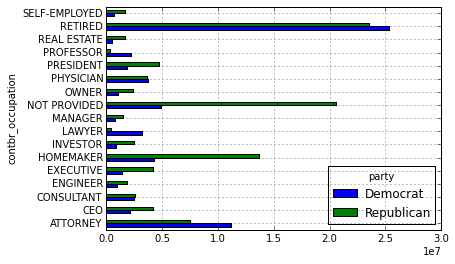

```python
over_2mm.plot(kind='barh')
```

```python
def get_top_amounts(group, key, n=5):
    totals = group.groupby(key)['contb_receipt_amt'].sum()

    # Order totals by key in descending order
    return totals.order(ascending=False)[-n:]

grouped = fec_mrbo.groupby('cand_nm')
grouped.apply(get_top_amounts, 'contbr_occupation', n=7)

grouped.apply(get_top_amounts, 'contbr_employer', n=10)
```

```
cand_nm        contbr_employer
Obama, Barack  SOLIYA                                3.0
               CARR ENTERPRISES                      3.0
               PENN STATE DICKINSON SCHOOL OF LAW    3.0
               CADUCEUS OCCUPATIONAL MEDICINE        3.0
               N.A.                                  3.0
               REAL ENERGY CONSULTING SERVICES       3.0
               JPDSYSTEMS, LLC                       3.0
               CASS REGIONAL MED. CENTER             2.5
               ARCON CORP                            2.0
               THE VICTORIA GROUP, INC.              2.0
Romney, Mitt   EASTHAM CAPITAL                       5.0
               GREGORY GALLIVAN                      5.0
               DIRECT LENDERS LLC                    5.0
               LOUGH INVESTMENT ADVISORY LLC         4.0
               WATERWORKS INDUSRTIES                 3.0
               WILL MERRIFIELD                       3.0
               HONOLD COMMUNICTAIONS                 3.0
               INDEPENDENT PROFESSIONAL              3.0
               UPTOWN CHEAPSKATE                     3.0
               UN                                    3.0
Name: contb_receipt_amt, dtype: float64
```

### Bucketing donation amounts

A useful way to analyze data is to use the `cut` function to partition the data into comparable buckets.

```python
bins = np.array([0, 1, 10, 100, 1000, 10000, 100000, 1000000, 10000000])
labels = pd.cut(fec_mrbo.contb_receipt_amt, bins)
labels
```

```
411      (10, 100]
412    (100, 1000]
413    (100, 1000]
414      (10, 100]
415      (10, 100]
416      (10, 100]
417    (100, 1000]
418      (10, 100]
419    (100, 1000]
420      (10, 100]
421      (10, 100]
422    (100, 1000]
423    (100, 1000]
424    (100, 1000]
425    (100, 1000]
```

[output cut: 18 more lines]

Grouping the data by name and bin, we get a histogram by donation size.

```python
grouped = fec_mrbo.groupby(['cand_nm', labels])
grouped.size().unstack(0)
```

```
cand_nm              Obama, Barack  Romney, Mitt
contb_receipt_amt
(0, 1]                         493            77
(1, 10]                      40070          3681
(10, 100]                   372280         31853
(100, 1000]                 153991         43357
(1000, 10000]                22284         26186
(10000, 100000]                  2             1
(100000, 1000000]                3           NaN
(1000000, 10000000]              4           NaN
```

The data shows that Barack Obama received significantly more contributions of smaller donation sizes. We can also sum the contribution amounts and normalize the data to view a percentage of total donations of each size by candidate:

```python
bucket_sums = grouped.contb_receipt_amt.sum().unstack(0)
bucket_sums
```

```
cand_nm              Obama, Barack  Romney, Mitt
contb_receipt_amt
(0, 1]                      318.24         77.00
(1, 10]                  337267.62      29819.66
(10, 100]              20288981.41    1987783.76
(100, 1000]            54798531.46   22363381.69
(1000, 10000]          51753705.67   63942145.42
(10000, 100000]           59100.00      12700.00
(100000, 1000000]       1490683.08           NaN
(1000000, 10000000]     7148839.76           NaN
```

```python
normed_sums = bucket_sums.div(bucket_sums.sum(axis=1), axis=0)
normed_sums
```

```
cand_nm              Obama, Barack  Romney, Mitt
contb_receipt_amt
(0, 1]                    0.805182      0.194818
(1, 10]                   0.918767      0.081233
(10, 100]                 0.910769      0.089231
(100, 1000]               0.710176      0.289824
(1000, 10000]             0.447326      0.552674
(10000, 100000]           0.823120      0.176880
(100000, 1000000]         1.000000           NaN
(1000000, 10000000]       1.000000           NaN
```

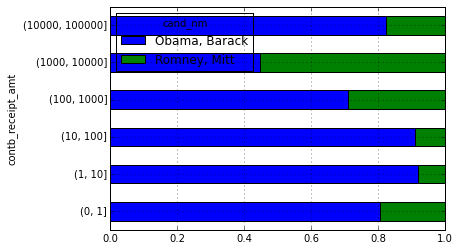

```python
normed_sums[:-2].plot(kind='barh', stacked=True)
```

### Donation statistics by state

We can also aggregate donations by candidate and state:

```python
grouped = fec_mrbo.groupby(['cand_nm', 'contbr_st'])
totals = grouped.contb_receipt_amt.sum().unstack(0).fillna(0)
totals = totals[totals.sum(1) > 100000]
totals[:10]
```

```
cand_nm    Obama, Barack  Romney, Mitt
contbr_st
AK             281840.15      86204.24
AL             543123.48     527303.51
AR             359247.28     105556.00
AZ            1506476.98    1888436.23
CA           23824984.24   11237636.60
CO            2132429.49    1506714.12
CT            2068291.26    3499475.45
DC            4373538.80    1025137.50
DE             336669.14      82712.00
FL            7318178.58    8338458.81
```

Additionally, we may obtain the relative percentage of total donations by state for each candidate.

```python
percent = totals.div(totals.sum(1), axis=0)
percent[:10]
```

```
cand_nm    Obama, Barack  Romney, Mitt
contbr_st
AK              0.765778      0.234222
AL              0.507390      0.492610
AR              0.772902      0.227098
AZ              0.443745      0.556255
CA              0.679498      0.320502
CO              0.585970      0.414030
CT              0.371476      0.628524
DC              0.810113      0.189887
DE              0.802776      0.197224
FL              0.467417      0.532583
```